# Homework_Data_Visualization

Nongnapat Veerabanjerd

2023-03-20

# Homework Data Visualization

Explore dataframe ‘diamonds’ and create visualizations.

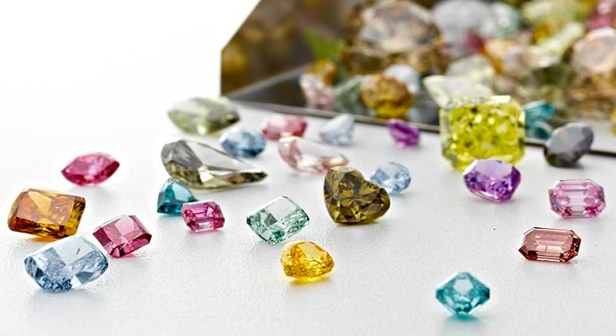

```r
library(tidyverse)
library(patchwork)

set.seed(42)
sample_dia <- diamonds %>% sample_n(5000)
sample_dia
```

```
## # A tibble: 5,000 × 10
##    carat cut       color clarity depth table price     x     y     z
##    <dbl> <ord>     <ord> <ord>   <dbl> <dbl> <int> <dbl> <dbl> <dbl>
##  1  0.39 Ideal     I     VVS2     60.8    56   849  4.74  4.76  2.89
##  2  1.12 Very Good G     SI2      63.3    58  4478  6.7   6.63  4.22
##  3  0.51 Very Good G     VVS2     62.9    57  1750  5.06  5.12  3.2
##  4  0.52 Very Good D     VS1      62.5    57  1829  5.11  5.16  3.21
##  5  0.28 Very Good E     VVS2     61.4    55   612  4.22  4.25  2.6
##  6  1.01 Fair      F     SI1      67.2    60  4276  6.06  6     4.05
##  7  0.4  Very Good D     VS1      60.8    59   954  4.74  4.76  2.89
##  8  0.9  Ideal     D     SI1      62.1    57  4523  6.18  6.25  3.86
##  9  0.33 Ideal     G     VVS1     62      55   838  4.45  4.49  2.77
## 10  0.71 Premium   G     VS2      62.1    62  2623  5.71  5.65  3.53
## # … with 4,990 more rows
```

We want to study the diamonds data for insight. First of all, we took a random sample of 5,000 (accounted for about 10%) of the total from diamonds data because the population data of diamonds is large.

### Chart 1 - Stacked Bar Chart by Cut and Color

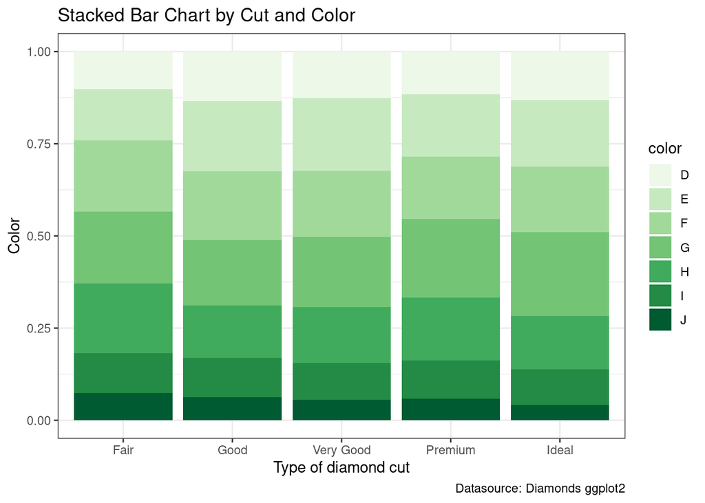

```r
ggplot(diamonds, aes(cut, fill = color)) +
  geom_bar(position = "fill") +
  theme_bw() +
  labs(title = "Stacked Bar Chart by Cut and Color",
       x = "Type of diamond cut",
       y = "Color",
       caption = "Datasource: Diamonds ggplot2") +
  scale_fill_brewer(type = "seq", palette = 5)
```

At the first chart, we want to know the proportions of colors by type of diamond cut using stacked bar chart. From the chart above, we can clearly see which color each type of diamonds has more and which color has less. For example, the color J of idea type has the smallest proportion of all ideal colors and other type.

### Chart 2 - Average Price of each Type of Diamond Cut

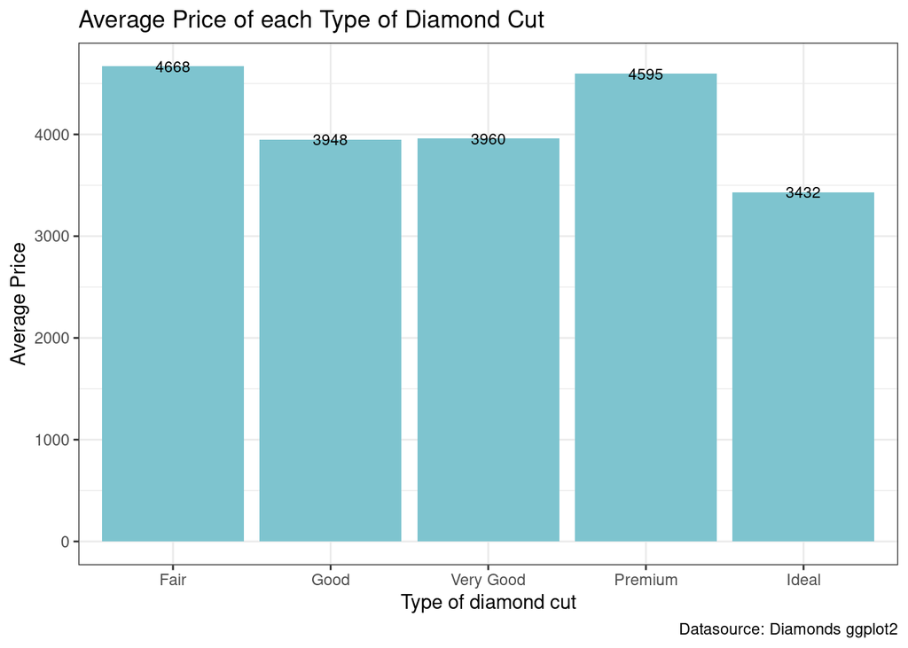

```r
sample_dia %>%
  group_by(cut) %>%
  summarise(avg_price = round(mean(price))) %>%
  ggplot(aes(x=cut, y=avg_price)) +
  geom_col(fill = "#7EC4CF") +
  theme_bw() +
  labs(title = "Average Price of each Type of Diamond Cut",
       x = "Type of diamond cut",
       y = "Average Price",
       caption = "Datasource: Diamonds ggplot2") +
  geom_text(aes(label=round(avg_price)), size = 3)
```

After we know the color proportion of each type of diamond cut, in chart 2, we want to know average the price by including all colors of each type. From the chart above, we can clearly see the fair type has the highest average price while the ideal type has the lowest price average.

### Chart 3 - Relationship between Carat and Price of Diamonds by Cut

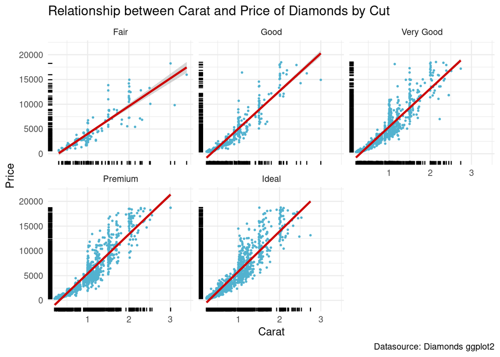

```r
ggplot(sample_dia, aes(carat, price)) +
  geom_point(size = 0.5, col = "#52B2CF") +
  geom_smooth(method = "lm", col = "red3") +
  geom_rug() +
  theme_minimal() +
  labs(title = "Relationship between Carat and Price of Diamonds by Cut",
       x = "Carat",
       y = "Price",
       caption = "Datasource: Diamonds ggplot2") +
  facet_wrap(~ cut, ncol = 3)
```

After we know the overall average price of each type of diamond cut, at chart 3, we will study relationship between carat and price separated by cut for ease of viewing. From chart, we will find that the higher the carat value, the higher the price. This relationship is called a positive relationship. Although separated by diamond cut, the results came out similar.

(We choose to use linear lines in chart instead of curved lines because we want to study the overall data. If we use curve lines, if a point appears below it, the graph will curve low, making it look like it is trending downward.)

### Chart 4 - Boxplot of Depth by Cut

### Chart 5 - Boxplot of Depth by Clarity

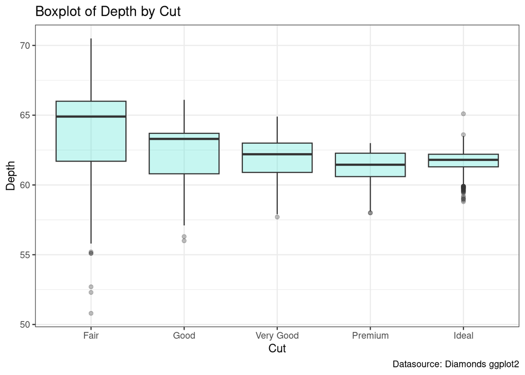

```r
p2 = ggplot(sample_dia, aes(clarity, depth)) +
  geom_boxplot(alpha = 0.5, fill = "skyblue") +
  theme_minimal() +
  labs(title = "Boxplot of Depth by Clarity",
       x = "Clarity",
       y = "Depth",
       caption = "Datasource: Diamonds ggplot2") +
  scale_color_brewer(type = "seq", palette = 5)

p1 = ggplot(sample_dia, aes(cut, depth)) +
  geom_boxplot(alpha = 0.3, fill = "turquoise") +
  theme_bw() +
  labs(title = "Boxplot of Depth by Cut",
       x = "Cut",
       y = "Depth",
       caption = "Datasource: Diamonds ggplot2")

p1
```

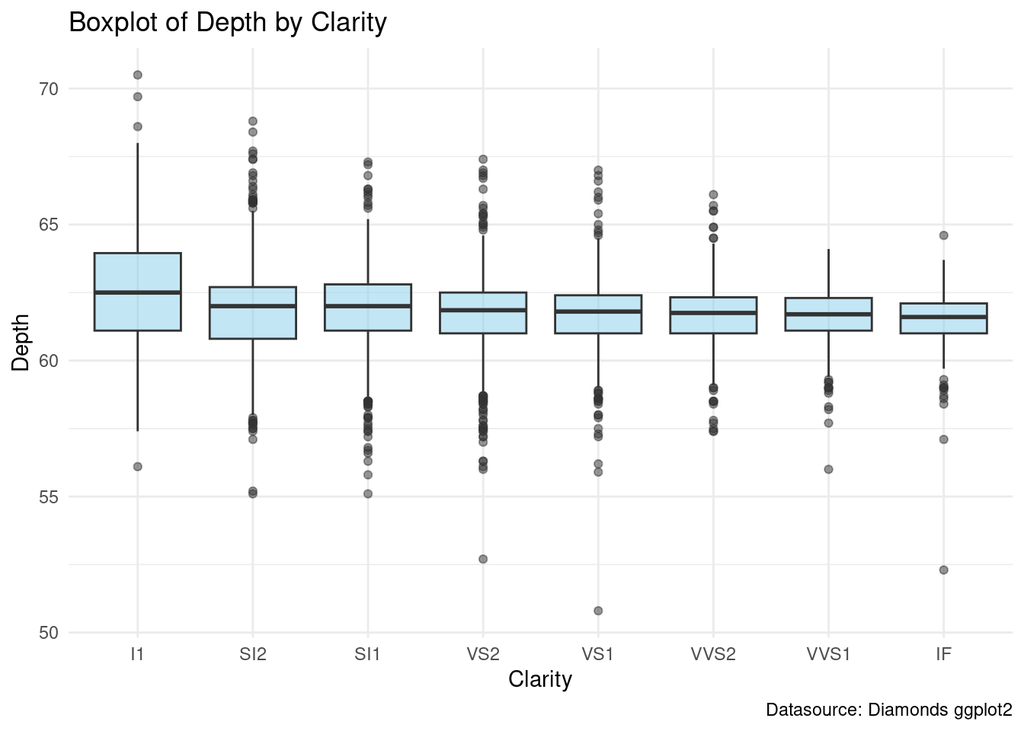

```r
p2
```

At chart 4 and 5, we want to study the depth by clarity and cut to see the quality of the diamonds. The depth value should be between 58-62.3%. A diamond that is too deep will cause the face of the diamond to become dark (also know as the nail head). A diamond is too thin will show the reflection of the edge of the diamond on the face of the diamond. If the edge of the diamond is a beard-girdle, it will create a fish eye.

From both charts, there are very few diamonds of low quality. Overall diamonds are of good quality.

### Chart 6 - Quantity of Cut by Clarity

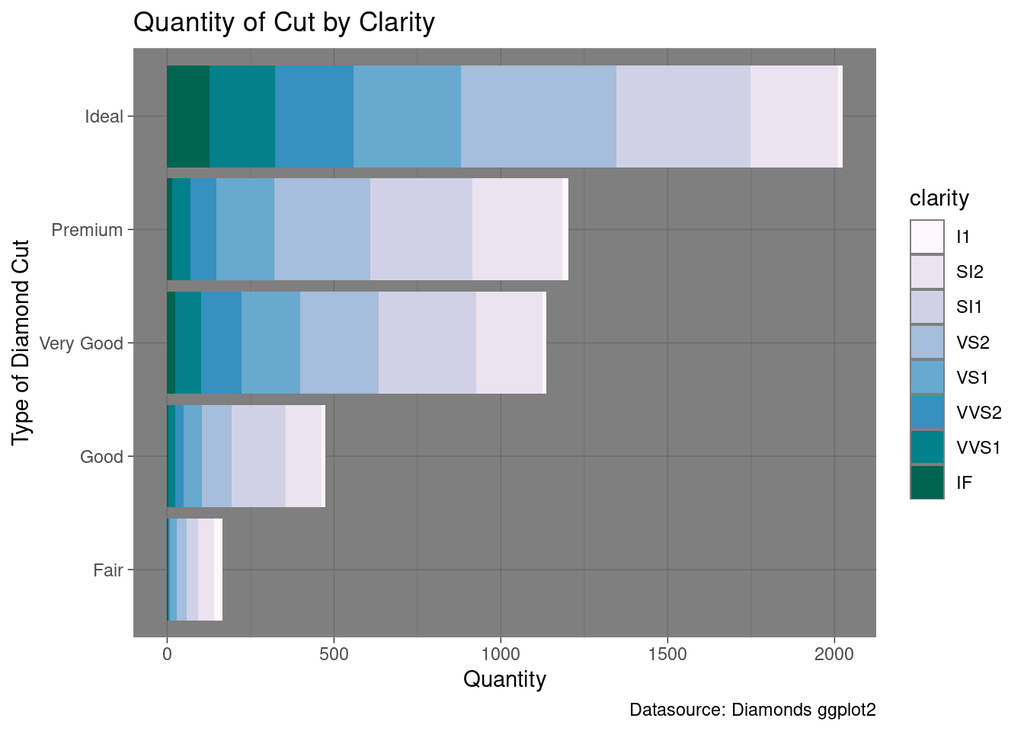

```r
sample_dia %>%
  count(cut, clarity) %>%
  ggplot(aes(x=n, y=cut, fill = clarity)) +
  geom_col() +
  theme_dark() +
  labs(title = "Quantity of Cut by Clarity",
       x = "Quantity",
       y = "Type of Diamond Cut",
       caption = "Datasource: Diamonds ggplot2") +
  scale_fill_brewer(type = "seq", palette = 10)
```

From the previous chart 5, we continue to study each type of cut has its clarity ratio by looking just the same type, not compared to other types. So we don’t compare to 100% like the first chart.

Clarity grade describes the clarity of diamonds starting from IF, VVS1, VVS2, VS1, VS2, SI1, SI2 and I1 (high level to low level). From further studies, we found that we should choose diamonds with a clarity of VS2 or higher because it will have a very small flaw. If it has large flaw, sometimes it will not affect the journey of light and the beauty of the diamond’s sparkle.

From the chart above, the ideal, premium and very good types contain diamonds of excellent clarity (more than half of the total). While good and fair types have more diamonds with poor clarity than good.

### Conclusion

We took 5,000 samples from the total number of data. From the study of all 6 charts, we can conclude that this diamond data contains good quality diamonds and relationship between carat and price is a positive relationship that makes sense.